# Visualización entrega I

Moisés Alfonso Guerrero Jiménez, Andrés Castaño Licona

2024-03-07

# Diseño de solución para predicción de radiación solar en diferentes escalas temporales de la comunidad de Castilla y León, España, para la gestión de proyectos de generación fotovoltaica.

## Descripción del problema

La crisis climática actual es un desafío crucial para la humanidad. El cambio climático tiene efectos significativos en el planeta y la vida humana, como el aumento del nivel del mar, fenómenos meteorológicos extremos y cambios en los patrones de precipitación. Los gases de efecto invernadero, especialmente de las centrales térmicas, son los principales impulsores del cambio climático. Las energías renovables, como la solar y la eólica, ofrecen una alternativa más limpia y asequible. Sin embargo, la transición hacia la energía solar fotovoltaica presenta desafíos técnicos y operativos debido a la variabilidad de la radiación solar.

## Radiación solar teórica

La radiación solar extraterrestre es la radiación electromagnética emitida por el sol que llega a la Tierra. Esta depende de varios factores, como la latitud, longitud y día del año.

- **Latitud:** Los puntos más cercanos al ecuador geográfico reciben en promedio más radiación solar extraterrestre que los puntos cercanos a los polos debido a la inclinación de la Tierra sobre su eje de rotación.
- **Longitud:** Aunque la longitud no afecta directamente la cantidad de radiación solar, se utiliza como referencia para estimar la zona horaria y la franja del día en la que se percibe luz solar.
- **Día del año:** La Tierra describe una órbita elíptica alrededor del sol, lo que significa que la distancia entre el sol y la Tierra varía a lo largo del año.

## Radiación solar percibida

La atmósfera de la Tierra está compuesta por diversos gases, vapor de agua y aerosoles, como partículas de polvo. Estos componentes interactúan con la radiación solar de diferentes maneras, modificando su intensidad y distribución.

- **Capa de ozono:** La capa de ozono tiene la capacidad de absorber la radiación ultravioleta del sol.
- **Aerosoles y vapor de agua:** Estos pueden absorber la radiación en el espectro infrarrojo.
- **Interacciones en la atmósfera:** A medida que la luz solar atraviesa la atmósfera, parte de ella puede ser reflejada, dispersada o absorbida por moléculas de aire (como nitrógeno, oxígeno y helio), vapor de agua, nubes y aerosoles .
- **Pronóstico de radiación solar:** Predecir este tipo de radiación es sumamente complejo, ya que depende de múltiples factores físicos, como la temperatura, el vapor de agua, la velocidad del viento y la presencia de núcleos de condensación. Además, la variabilidad extrema introducida por el cambio climático también influye .
- **Nubosidad:** Las nubes actúan como moderadores de la radiación solar. Pueden reflejar y absorber parte de la radiación, lo que afecta la cantidad que llega a la superficie terrestre. El tipo, espesor y tamaño de las nubes determinan cuánta radiación se refleja o absorbe.

### Problema de negocio

En los sistemas de generación de energía, es crucial mantener un equilibrio adecuado entre la demanda y la oferta. Las predicciones de estos dos componentes permiten a los participantes del sistema (como generadores, distribuidores, operadores y reguladores) establecer las dinámicas del mercado energético, incluyendo la compra y venta de energía.

Dada la creciente implementación de proyectos fotovoltaicos en todo el mundo, es altamente deseable predecir la radiación solar en diferentes escalas temporales. Estas predicciones tienen aplicaciones amplias, como seleccionar ubicaciones óptimas para parques solares, estimar el equilibrio entre oferta y demanda, establecer franjas horarias para el despacho de energía y administrar el almacenamiento de energía. Además, ayudan a planificar ciclos de mantenimiento y transacciones en el mercado energético.

Para estimar la radiación solar percibida en un punto de la Tierra, se utilizan modelos físicos o estadísticos. Los modelos físicos aplican leyes físicas para calcular la cantidad de radiación solar que llega a la superficie terrestre, considerando las interacciones con la atmósfera. Los modelos estadísticos se basan en datos históricos de radiación solar para predecir la radiación futura.

### Aproximación desde la analítica de datos

El enfoque abordado en este trabajo se centra en analítica de datos, utilizando métodos estadísticos y machine learning para predecir la radiación solar en diferentes escalas temporales.

- **Análisis estadístico:** Se identifican dependencias entre predictores (variables meteorológicas). El tratamiento de datos y los modelos se combinan, utilizando tanto modelos de aprendizaje supervisado para predecir la radiación solar a partir de otras variables meteorológicas (incluida la radiación solar teórica) como modelos diseñados para el análisis de series de tiempo.
- **Enfoque conjunto:** Se sigue un enfoque de aprendizaje conjunto, integrando predicciones de los modelos desarrollados. Esto permite combinar las fortalezas de diferentes enfoques de modelado para mejorar la precisión de las predicciones.

## Datos

Los datos usados hacen parte de un repositorio abierto con licencia Creative Commons Attribution, que contiene mediciones de radiación horizontal global solar (GHI), para el período 2002-2019, con frecuencia de 30 minutos, para 37 estaciones de Castilla y León, en España.

Los datos fueron publicados por integrantes del Departamento de Ingeniería Topográfica y Cartográfica de la Escuela Técnica Superior de Ingenieros en Topografía, Geodesia y Cartografía, Universidad Politécnica de Madrid, y se encuentran disponibles para su uso con fines de investigación en un repositorio público. Los datos contienen información de marca de tiempo, datos meteorológicos (precipitación, temperatura, humedad relativa, radiación solar, velocidad y dirección del viento) y geoespaciales (latitud y longitud).

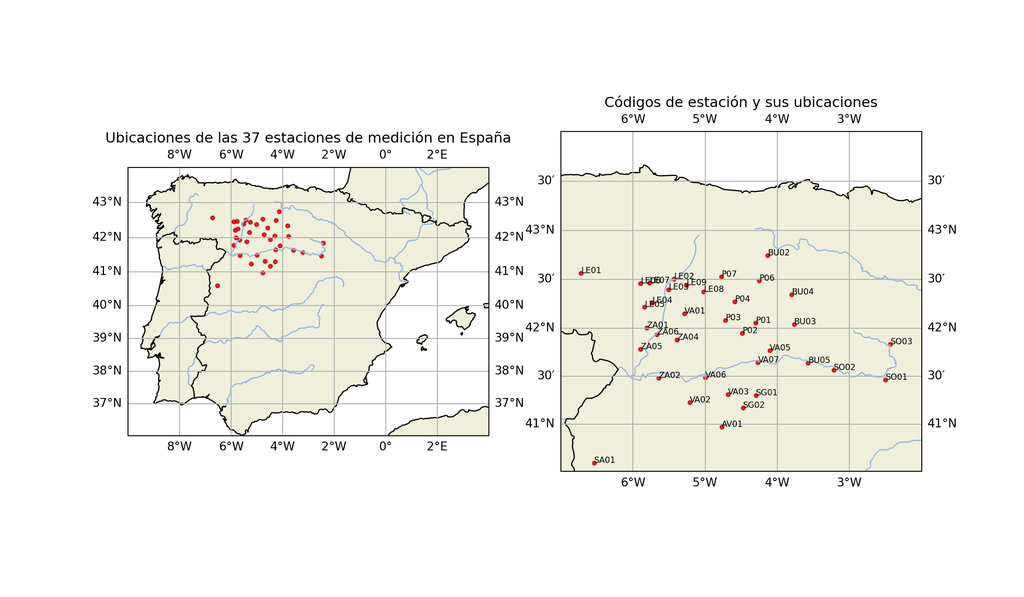

Los datos incluyen mediciones realizadas para cada una de las 37 estaciones relacionadas incluyendo:

- **Código:** Código único de la estación en la cual se realizaron las mediciones.
- **Ubicación:** Indica el nombre de la estación de medición de acuerdo a su ubicación.
- **Fecha (AAAA-MM-DD):** Hace referencia a la fecha en la cual se realizaron las mediciones (UTC).
- **Hora (HHMM):** Indica la hora en la cual se realizó la medición para la fecha correspondiente (UTC).
- **Precipitación (mm):** Precipitaciones medidas en milímetros en la ubicación de la estación de medición.
- **Temperatura (°C):** Temperatura en grados celsius medida en la ubicación de la estación meteorológica.
- **Humedad relativa (%):** Indica el porcentaje de humedad medido.
- **Radiación ($W/m^{2}$):** Medición de la radiación solar global horizontal (GHI).
- **Vel. viento ($m/s$):** Velocidad del viento medida en $m/s$.
- **Dir. viento (°):** Dirección del viento en grados.

## Analítica descriptiva

Para visualizar el comportamiento de la radiación solar horizontal disponible a lo largo del año, se realiza una comparación entre los datos medidos y los datos teóricos esperados en la ubicación de cada una de las estaciones meteorológicas.

A continuación se muestra un ejemplo para el caso particular de la estación de *Nava de Arévalo (Código de estación AV01)*, donde se toman los datos de la estación de medición durante el año 2002 como el GHI medido, y por otro lado,haciendo uso de latitud y longitud, así como la longitud del uso horario, se obtienen los valores de GHI teórico.

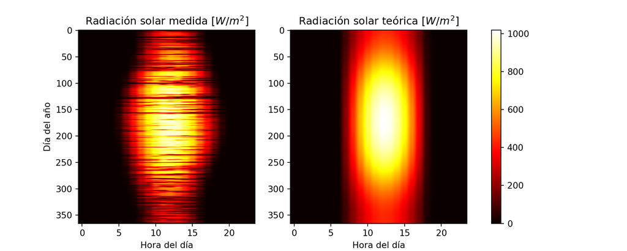

[figure not shown]